# Homework 4

Claire Friou (cnf2109)

4/24/2019

1. Reject-Accept Method

Let random variable X denote the temperature at which a certain chemical reaction takes place.

Perform the following tasks: 1. Determine the maximum of f(x). Find an envelope function e(x) by using a uniform distribution for g(x) and setting e(x) = maxx{f(x)}.

```r
f<-function(x){
  return(ifelse((x < -1 | x > 2),0,(1/9)*(4-x^2)))
}
xmax<-0
f.max<-((1/9)*(4-xmax^2))

e<-function(x){
  return(ifelse((x < -1 | x > 2),Inf,f.max))
}
```

2. Using the Accept-Reject Algorithm, write a program that simulates 1000 draws from the probability density function f(x).

```r
n.samps<-1000
counter<-0
samps<-numeric(n.samps)
while(counter<n.samps){
  y<-runif(1)
  u<-runif(1) #u for uniform distribution
  if(u<f(y)/e(y)){
    counter<-counter+1
    samps[counter]<-y
  }
}
```

3. Plot a histogram of your simulated data with the density function f overlayed in the graph. Label your plot appropriately.

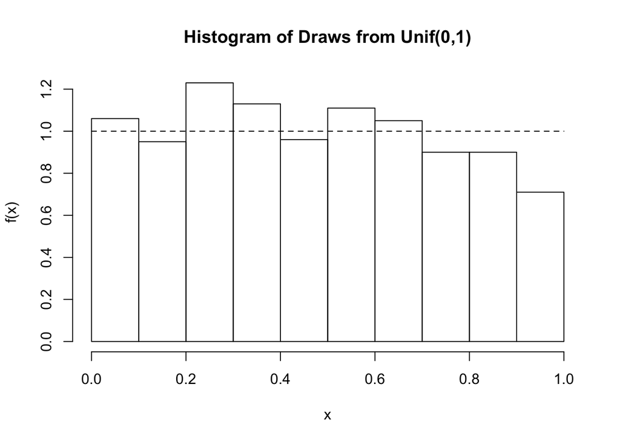

```r
x<-seq(0,1,length=100)
hist(samps,prob=T,ylab="f(x)",xlab="x",main="Histogram of Draws from Unif(0,1)")
lines(x,dunif(x,0,1),lty=2)
```

2. Regression and Empirical Size

2.1 Regression We work with the grocery retailer dataset from Canvas. The description follows: A large national grocery retailer tracks productivity and costs of its facilities closely. Consider a data set obtained from a single distribution center for a one-year period. Each data point for each variable represents one week of activity. The variables included are num- ber of cases shipped in thousands (X1), the indirect costs of labor as a percentage of total costs (X2), a qualitative predictor called holiday that is coded 1 if the week has a holiday and 0 otherwise (X3), and total labor hours (Y).

Perform the following tasks: 4. Read in the grocery retailer dataset. Name the dataset grocery.

```r
setwd("~/Desktop/Applied Stats - R/Homework 4")
grocery<-read.table("grocery.txt",header=TRUE,as.is=TRUE)
```

5. Use the least squares equation to estimate regression model. To estimate the model, use the linear model function in R, i.e., use lm().

```r
fit<-lm(grocery$Y~grocery$X1+grocery$X2+grocery$X3,data=grocery)
fit
```

```
##
## Call:
## lm(formula = grocery$Y ~ grocery$X1 + grocery$X2 + grocery$X3,
##     data = grocery)
##
## Coefficients:
## (Intercept)   grocery$X1   grocery$X2   grocery$X3
##   4149.8872       0.7871     -13.1660     623.5545
```

```r
residuals.lm(fit)
```

```
##           1           2           3           4           5           6
##  -32.063483  169.205091  -21.825426  -54.119552   75.933724   28.000660
##           7           8           9          10          11          12
## -156.684401 -166.983381 -136.691019  275.783546  132.059842  -33.540598
##          13          14          15          16          17          18
##  -59.173782 -215.535629   22.975644 -117.076677  178.568096  -75.863154
##          19          20          21          22          23          24
##  108.947943 -183.565972  -49.165210   11.662167 -120.279732   80.569854
##          25          26          27          28          29          30
##   48.807558  -23.519661   78.869281  -58.398630   61.303251  -23.214763
##          31          32          33          34          35          36
## -138.978271 -264.053024  218.752742  235.960794 -229.055311  -67.763118
##          37          38          39          40          41          42
## -139.284659  288.397234 -108.609359  295.751820   29.065887   80.555515
##          43          44          45          46          47          48
##  107.399309   55.197555   37.772702  -80.508888 -144.901536  -28.753312
##          49          50          51          52
##    2.731302  225.697849 -184.877629   64.516810
```

2.2 Test for Slope

```r
summary(fit)
```

```
##
## Call:
## lm(formula = grocery$Y ~ grocery$X1 + grocery$X2 + grocery$X3,
##     data = grocery)
##
## Residuals:
##     Min      1Q  Median      3Q     Max
## -264.05 -110.73  -22.52   79.29  295.75
##
## Coefficients:
##              Estimate Std. Error t value Pr(>|t|)
## (Intercept) 4149.8872   195.5654  21.220  < 2e-16 ***
## grocery$X1     0.7871     0.3646   2.159   0.0359 *
## grocery$X2   -13.1660    23.0917  -0.570   0.5712
## grocery$X3   623.5545    62.6409   9.954 2.94e-13 ***
## ---
## Signif. codes:  0 '***' 0.001 '**' 0.01 '*' 0.05 '.' 0.1 ' ' 1
##
## Residual standard error: 143.3 on 48 degrees of freedom
## Multiple R-squared:  0.6883, Adjusted R-squared:  0.6689
## F-statistic: 35.34 on 3 and 48 DF,  p-value: 3.316e-12
```

Test the manager’s claim in (3) using R functions lm() and summary()

```r
summary(fit)$coefficients[2,4]
```

```
## [1] 0.0358765
```

B1 is not equal to zero thus we accept the alternative hypothesis.

2.3 Sampling Distribution The goal of this section is to simulate the sampling distribution of the t-statistic.

5. Write a loop that simulates the sampling distribution of the t-statistic under null hypothesis (3) with the multiple linear regression model (2).

```r
t.stat<-c()

for(i in 1:10000){
  Y.model<-lm(grocery$Y~I(15*grocery$X2+620*grocery$X3+4200),data=grocery)
  t.stat<-c(t.stat,summary(Y.model)[[4]])
  i<-i+1
}
head(t.stat,6)
```

```
## [1] 3.362871e+00 9.948834e-01 4.519721e+02 1.030334e-01 7.440439e-03
## [6] 9.655934e+00
```

7. Plot a histogram of the simulated sampling distribution. Overlay the correct t-density of this histogram. Plot the density in green and set breaks=40 in the histogram. Make sure to label the plot appropriately.

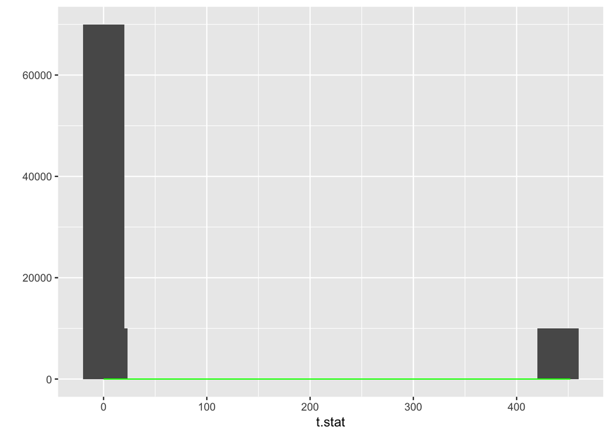

```r
library(ggplot2)
qplot(t.stat,binwidth=40)+geom_histogram()+stat_function(fun=dnorm, color="green")
```

8. Recall the signficance level of a testing procedure.

```r
size<-function(level=0.10){
  p<-rep(0,length(t.stat))
  for(i in 1:length(t.stat)){
    sig<-t.test(t.stat)
    p[i]<-sig$p.value
    size.list<- mean(p<=level)
  }
  return(list(empirical.size=size.list))
}
#size(level=0.05)
#size(level=0.01)
#size(level=0.10)
```